# Assignment 1 Econ220

Dr. Paloma Lopezdemesa

08 12月 2019

# Download data into R and Data Cleaning

```r
# Load data into R, the data is already in R format
load("~/Desktop/EMORY2019Fall/econ220/Econ220DataF2019_ano.Rdata")

# Let's give it another name so it is easier to work with it and select the variables that we will use
ProdataSample<-Econ220DataF2019_ano

# rescale the numbers that are in text to a range 0-4
ProdataSample$q17[ProdataSample$q17=="3.89/4.35"]<-3.57
ProdataSample$q17[ProdataSample$q17=="3.9/4"]<-3.9
ProdataSample$q17[ProdataSample$q17=="36/45 (International Baccalaureate)"]<-3.2
ProdataSample$q17[ProdataSample$q17=="4.29/4.5"]<-3.81
ProdataSample$q17[ProdataSample$q17=="4.3/4.5"]<-3.82
ProdataSample$q17[ProdataSample$q17=="5.6/6.0"]<-3.73
ProdataSample$q17[ProdataSample$q17=="8.5 out of 10"]<-3.4
ProdataSample$q17[ProdataSample$q17=="95"]<-3.8
ProdataSample$q17[ProdataSample$q17=="N/A"]<-NA
# There are some numerical values that outside the range I asummed that the ones below 4.5 are in the 0-4.5 range.
#Only one value is 5 thisone get converted to 4
ProdataSample$q17[ProdataSample$q17=="5"]<-4

# Clean up q22 to understandable data
ProdataSample$q22[ProdataSample$q22=="1&2"]<-2
ProdataSample$q22[ProdataSample$q22=="2 times"]<-2
ProdataSample$q22[ProdataSample$q22=="5-Apr"]<-5

#make the variable numeric
ProdataSample$q17<-as.numeric(ProdataSample$q17)
ProdataSample$q22<-as.numeric(ProdataSample$q22)


# use the function mutate and ifelse to change the values to waht you need
# Example mutate(var1=ifelse(test_expression, x, y))
# Here, test_expression must be a logical vector (or an object that can be coerced to logical). The return value is a vector with the same length as test_expression.
ProdataSample<-ProdataSample %>% mutate(q17=ifelse(q17<=4,q17,q17*4/4.5))


# Change the levels of the year variable so it has the right order.
ProdataSample$year <- ordered(ProdataSample$year,levels=c("Freshmen","Sophomore","Junior","Senior"))
```

# Descriptive statistics of the data

First make a summary of the data excluding a couple of factor variables. See below

```r
summary(select(ProdataSample, "year", "q8", "q17", "q22"))
```

```
##         year          q8             q17             q22
##  Freshmen : 2   Min.   :2.000   Min.   :3.000   Min.   :0.000
##  Sophomore:35   1st Qu.:3.230   1st Qu.:3.700   1st Qu.:2.000
##  Junior   :55   Median :3.638   Median :3.836   Median :3.000
##  Senior   :23   Mean   :3.527   Mean   :3.799   Mean   :3.252
##  NA's     : 2   3rd Qu.:3.848   3rd Qu.:4.000   3rd Qu.:5.000
##                 Max.   :4.000   Max.   :4.000   Max.   :7.000
##                 NA's   :3       NA's   :3       NA's   :2
```

Now let’s look at statistics by sex. What is the mean and max of all these variables by sex? Use the function summarise_all() use the console to inderstand how this function works. You also have to deal with NA values.

```r
# make the sex variable a factor
ProdataSample$sex<- factor(ProdataSample$sex, level=c("Female", "Male"))
# ProdataSample %>%select("sex","q22")%>% group_by(sex)
# Checking if men's mean in q22 has edge cases but couldn't found. Men's mean is not accurate for some reason...

# Calculate the means and max
ProdataSample%>%select("sex", "year", "q8", "q17", "q22") %>% na.omit() %>% group_by(sex) %>% summarise("q8_mean"= round(mean(q8),2),"q17_mean"= round(mean(q17),2),"q22_mean"= round(mean(q22),2),"q8_max"=max(q8), "q17_max"=max(q17), "q22_max"=max(q22))
```

```
## # A tibble: 2 x 7
##   sex    q8_mean q17_mean q22_mean q8_max q17_max q22_max
##   <fct>    <dbl>    <dbl>    <dbl>  <dbl>   <dbl>   <dbl>
## 1 Female    3.57     3.87     3.05      4       4       7
## 2 Male      3.51     3.76     3.37      4       4       7
```

What is the correlation between GPA and High School GPA by gender.

```r
#use the knirt option warning to eliminate messages.
ProdataSample%>%select("sex", "q8", "q17") %>% na.omit() %>% group_by(sex) %>% summarise("Cor_HSGPA_GPA" = round(cor(q8,q17),3))
```

```
## # A tibble: 2 x 2
##   sex    Cor_HSGPA_GPA
##   <fct>          <dbl>
## 1 Female         0.423
## 2 Male           0.086
```

```r
# dont know how to show third row NAs
```

# Graphs

Make the following graphs * Show the relationship between weekly workouts and GPA by gender and by year. Figure out how to get rid of the NA in the sex variable. * Use a column graph to show the average workouts per week by gender. * Use a column graph to show the average GPA by sex and race. Figure out how to make the tick labels in the x axis look like the graph below. Hint: use scale_x_discrete() to modify the levels of the factor variable.

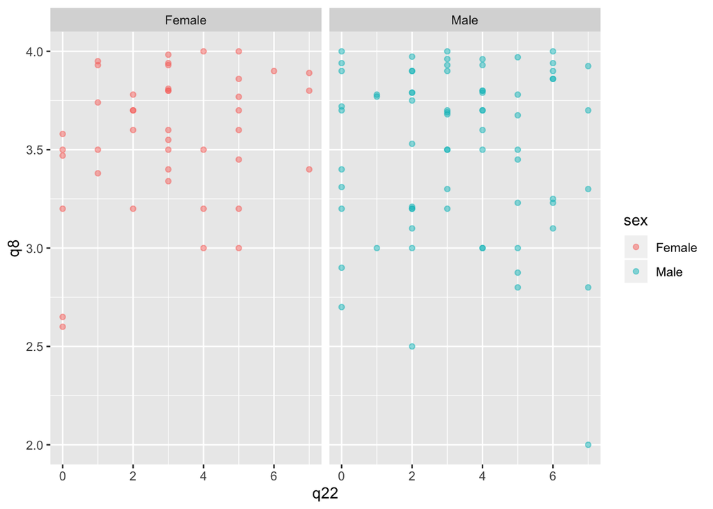

```r
ProdataSample <- ProdataSample %>%
  filter(!is.na(q8))
ggplot(data=ProdataSample, mapping=aes(x=q22, y=q8, color=sex))+ geom_point(alpha=0.5)+facet_wrap(~sex)
```

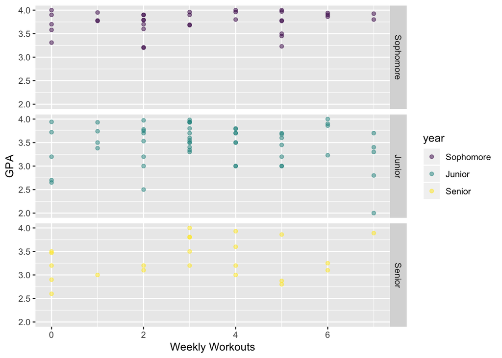

```r
ProdataSample <- ProdataSample %>%
  filter(!is.na(year))
ggplot(data=ProdataSample, mapping=aes(x=q8, y=q22, color=year))+ geom_point(alpha=0.5)+facet_wrap(~year)+ylab("Weekly Workouts") + xlab("GPA")+ coord_flip()+facet_grid(year~.)
```

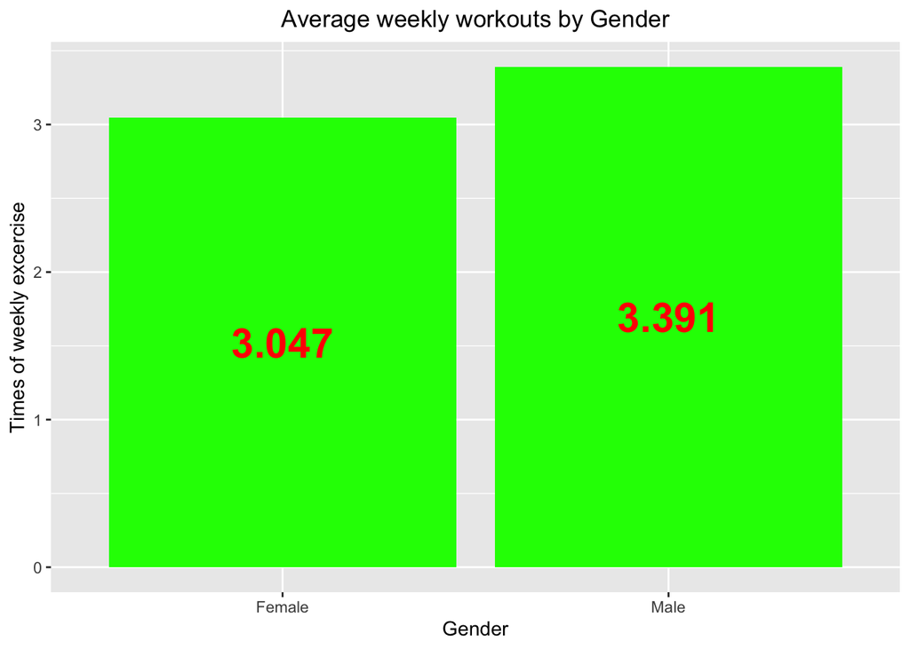

```r
ProdataSample %>%
  filter(!is.na(q22)) %>% # need to remove the one na but can't change the actual dataset because later still need it
  group_by(sex) %>%
  summarize(Times_of_weekly_excercise=round(mean(q22),3)) %>%
  ggplot(mapping=aes(x=sex, y=Times_of_weekly_excercise,label=Times_of_weekly_excercise,))+
  geom_col(fill="green")+
   geom_text(size=8, fontface=2, color="red", position = position_stack(vjust = 0.5))+
  ylab("Times of weekly excercise") + xlab("Gender")+
  ggtitle("Average weekly workouts by Gender") +
   theme(plot.title = element_text(hjust = 0.5))
```

```r
# Male numbers somehow wrong
```

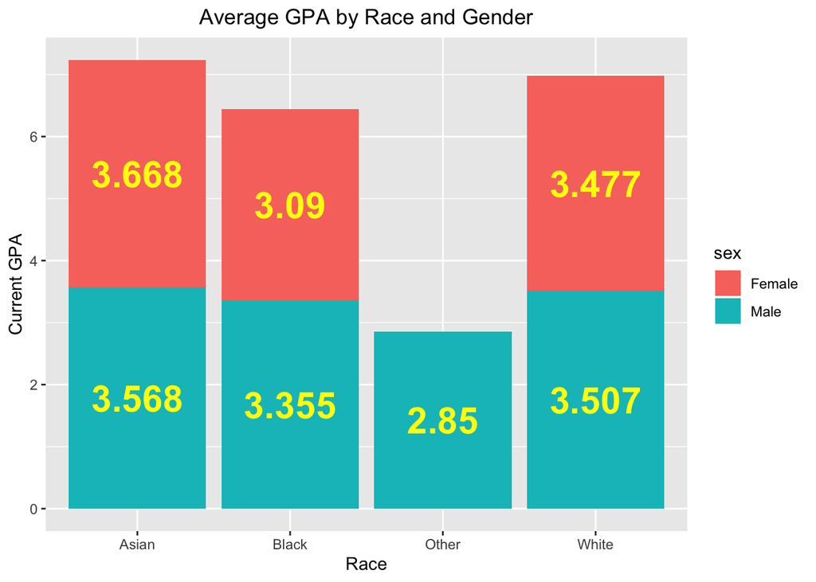

```r
ProdataSample %>%
  group_by(sex, race) %>%
  summarize(gpa=round(mean(q8),3)) %>%
  ggplot(mapping=aes(x=race, y=gpa,label=gpa, fill=sex))+ geom_col()+
   geom_text(size=8, fontface=2, color="yellow", position = position_stack(vjust = 0.5))+
  ylab("Current GPA") + xlab("Race")+
  ggtitle("Average GPA by Race and Gender") +scale_x_discrete(labels=c("Asian", "Black", "Other", "White")) +
   theme(plot.title = element_text(hjust = 0.5))
```